# study1 preprocessing

anonymous

2024-12-10

```r
knit_by_pkgdown <- !is.null(knitr::opts_chunk$get("fig.retina"))
knitr::opts_chunk$set(
  warning = TRUE, # show warnings during codebook generation
  message = TRUE, # show messages during codebook generation
  error = TRUE, # do not interrupt codebook generation in case of errors,
                # TRUE is usually better for debugging
  echo = TRUE  # show R code
)

library(pacman)
pacman::p_load(tidyverse, here, codebook)
ggplot2::theme_set(ggplot2::theme_bw())
```

# 1 Read data

```r
codebook::codebook(d)
```

```
## No missing values.
```

### 1.0.1 Metadata

#### 1.0.1.1 Description

**Dataset name**: Model predictions for the 4 models

Data frame describing the model predictions of the 4 models. This data frame is generated by the study1_preprocessing.Rmd script. The values in the dataset represent similarity scores with 0 being very similar and 1 being very disimilar. These values will be used to build model RDMs for comparison with the empirical RDMs from the Causal Task and Sorting Task

**Metadata for search engines**

- **Date published**: 2025-02-02

| x |
| --- |
| itemA |
| itemB |
| theor1_Mind-Body-Action |
| theor2_PerCog-OdActSpAct-BodyStimBodynoStim |
| theor3_Physical-Ethereal |
| theor4_cosine_similarity |

## 1.1 Variables

### 1.1.1 itemA

First item among item pairs in the Causal Task. This is the cause.

#### 1.1.1.1 Distribution

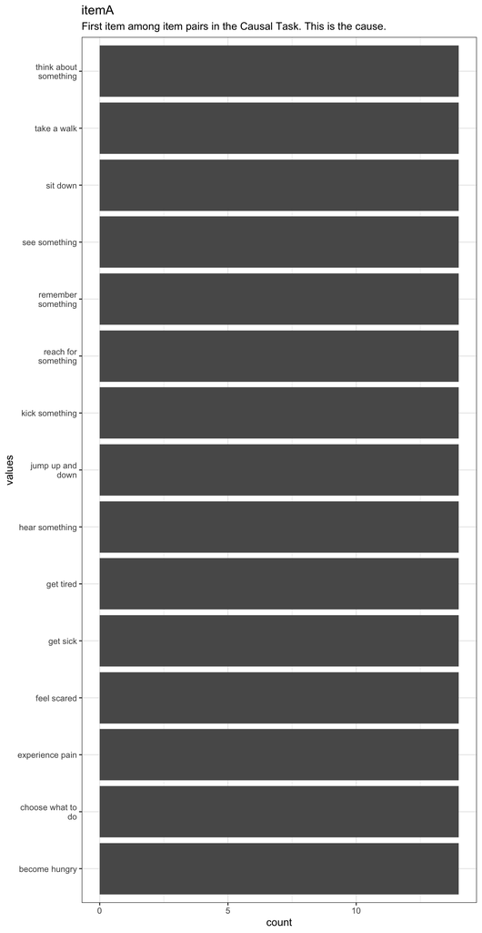

Distribution of values for itemA

0 missing values.

#### 1.1.1.2 Summary statistics

| name | label | data_type | n_missing | complete_rate | n_unique | empty | min | max | whitespace |
| --- | --- | --- | --- | --- | --- | --- | --- | --- | --- |
| itemA | First item among item pairs in the Causal Task. This is the cause. | character | 0 | 1 | 15 | 0 | 8 | 21 | 0 |

### 1.1.2 itemB

second item among item pairs in the Causal Task. This is the effect.

#### 1.1.2.1 Distribution

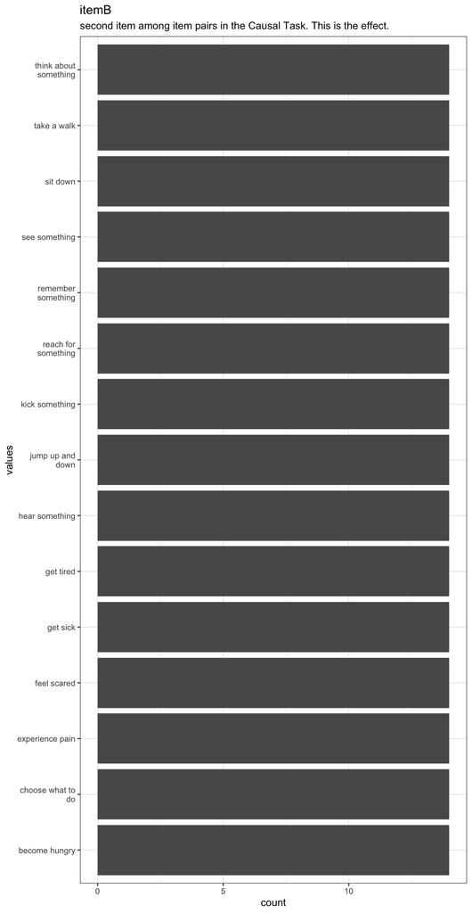

Distribution of values for itemB

0 missing values.

#### 1.1.2.2 Summary statistics

| name | label | data_type | n_missing | complete_rate | n_unique | empty | min | max | whitespace |
| --- | --- | --- | --- | --- | --- | --- | --- | --- | --- |
| itemB | second item among item pairs in the Causal Task. This is the effect. | character | 0 | 1 | 15 | 0 | 8 | 21 | 0 |

### 1.1.3 theor1_Mind-Body-Action

Similarity value assigned to each item pairing for the Mind, Body, Action model. For example, a similarity of 0 for `hear something` and `see something` indicated the model predicts these two items are very similar, since they are both predicted to be in the Mind category

#### 1.1.3.1 Distribution

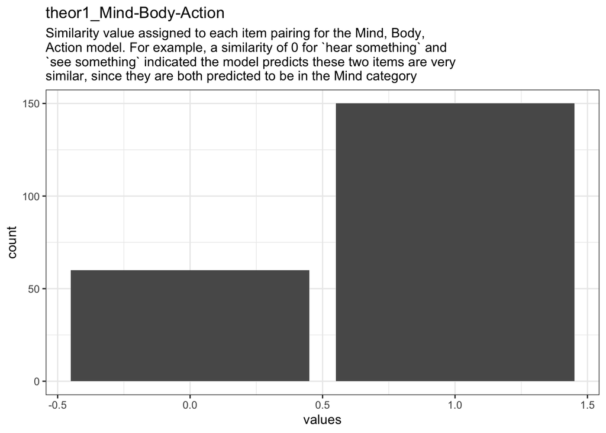

Distribution of values for theor1_Mind-Body-Action

0 missing values.

#### 1.1.3.2 Summary statistics

| name | label | data_type | n_missing | complete_rate | min | median | max | mean | sd | hist |
| --- | --- | --- | --- | --- | --- | --- | --- | --- | --- | --- |
| theor1_Mind-Body-Action | Similarity value assigned to each item pairing for the Mind, Body, Action model. For example, a similarity of 0 for `hear something` and `see something` indicated the model predicts these two items ar… | numeric | 0 | 1 | 0 | 1 | 1 | 0.7142857 | 0.4528334 | ▃▁▁▁▇ |

### 1.1.4 theor2_PerCog-OdActSpAct-BodyStimBodynoStim

Similarity value assigned to each item pairing for the Fine grained Mind, Body Action model. For example, a similarity of 0 for `hear something` and `see something` indicated the model predicts these two items are very similar, since they are both predicted to be in the Perceptual Items category

#### 1.1.4.1 Distribution

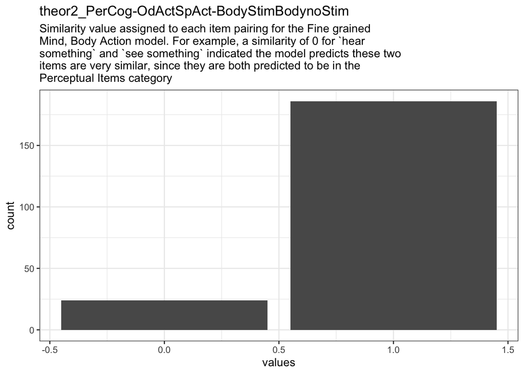

Distribution of values for theor2_PerCog-OdActSpAct-BodyStimBodynoStim

0 missing values.

#### 1.1.4.2 Summary statistics

| name | label | data_type | n_missing | complete_rate | min | median | max | mean | sd | hist |
| --- | --- | --- | --- | --- | --- | --- | --- | --- | --- | --- |
| theor2_PerCog-OdActSpAct-BodyStimBodynoStim | Similarity value assigned to each item pairing for the Fine grained Mind, Body Action model. For example, a similarity of 0 for `hear something` and `see something` indicated the model predicts these … | numeric | 0 | 1 | 0 | 1 | 1 | 0.8857143 | 0.3189182 | ▁▁▁▁▇ |

### 1.1.5 theor3_Physical-Ethereal

Similarity value assigned to each item pairing for the Physical and Psychological/Ethereal model. For example, a similarity of 0 for `hear something` and `see something` indicated the model predicts these two items are very similar, since they are both predicted to be in the Ethereal or psychological items category

#### 1.1.5.1 Distribution

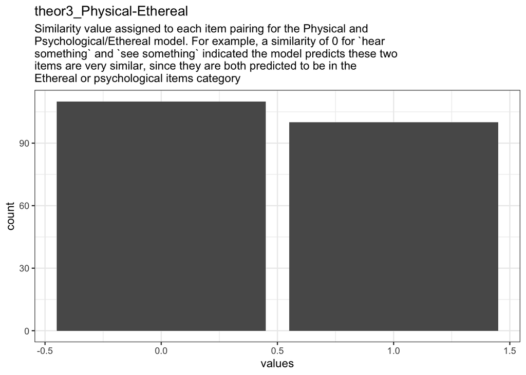

Distribution of values for theor3_Physical-Ethereal

0 missing values.

#### 1.1.5.2 Summary statistics

| name | label | data_type | n_missing | complete_rate | min | median | max | mean | sd | hist |
| --- | --- | --- | --- | --- | --- | --- | --- | --- | --- | --- |
| theor3_Physical-Ethereal | Similarity value assigned to each item pairing for the Physical and Psychological/Ethereal model. For example, a similarity of 0 for `hear something` and `see something` indicated the model predicts t… | numeric | 0 | 1 | 0 | 0 | 1 | 0.4761905 | 0.5006262 | ▇▁▁▁▇ |

### 1.1.6 theor4_cosine_similarity

Similarity value assigned to each item pairing for USE word embeddings model

#### 1.1.6.1 Distribution

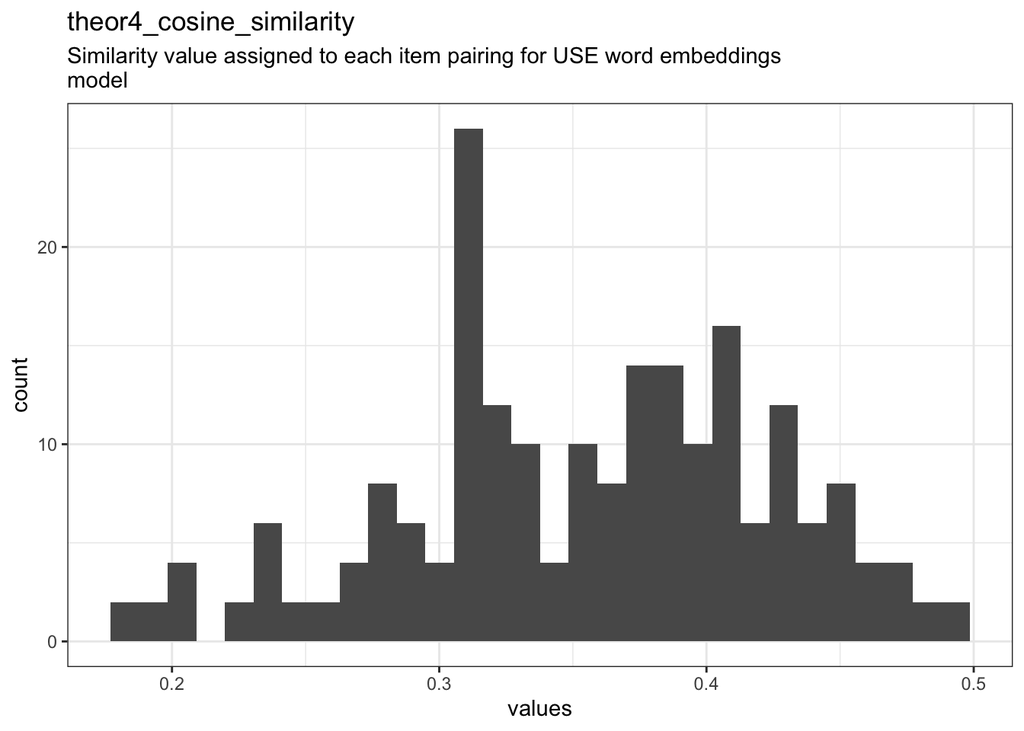

Distribution of values for theor4_cosine_similarity

0 missing values.

#### 1.1.6.2 Summary statistics

| name | label | data_type | n_missing | complete_rate | min | median | max | mean | sd | hist |
| --- | --- | --- | --- | --- | --- | --- | --- | --- | --- | --- |
| theor4_cosine_similarity | Similarity value assigned to each item pairing for USE word embeddings model | numeric | 0 | 1 | 0.18 | 0.36 | 0.5 | 0.3551498 | 0.0692231 | ▂▃▇▇▃ |

## 1.2 Missingness report

## 1.3 Codebook table

| name | label | data_type | n_missing | complete_rate | n_unique | empty | min | median | max | mean | sd | whitespace | hist |
| --- | --- | --- | --- | --- | --- | --- | --- | --- | --- | --- | --- | --- | --- |
| itemA | First item among item pairs in the Causal Task. This is the cause. | character | 0 | 1 | 15 | 0 | 8 | NA | 21 | NA | NA | 0 | NA |
| itemB | second item among item pairs in the Causal Task. This is the effect. | character | 0 | 1 | 15 | 0 | 8 | NA | 21 | NA | NA | 0 | NA |
| theor1_Mind-Body-Action | Similarity value assigned to each item pairing for the Mind, Body, Action model. For example, a similarity of 0 for `hear something` and `see something` indicated the model predicts these two items ar… | numeric | 0 | 1 | NA | NA | 0.00 | 1.00 | 1.0 | 0.7142857 | 0.4528334 | NA | ▃▁▁▁▇ |
| theor2_PerCog-OdActSpAct-BodyStimBodynoStim | Similarity value assigned to each item pairing for the Fine grained Mind, Body Action model. For example, a similarity of 0 for `hear something` and `see something` indicated the model predicts these … | numeric | 0 | 1 | NA | NA | 0.00 | 1.00 | 1.0 | 0.8857143 | 0.3189182 | NA | ▁▁▁▁▇ |
| theor3_Physical-Ethereal | Similarity value assigned to each item pairing for the Physical and Psychological/Ethereal model. For example, a similarity of 0 for `hear something` and `see something` indicated the model predicts t… | numeric | 0 | 1 | NA | NA | 0.00 | 0.00 | 1.0 | 0.4761905 | 0.5006262 | NA | ▇▁▁▁▇ |
| theor4_cosine_similarity | Similarity value assigned to each item pairing for USE word embeddings model | numeric | 0 | 1 | NA | NA | 0.18 | 0.36 | 0.5 | 0.3551498 | 0.0692231 | NA | ▂▃▇▇▃ |

**JSON-LD metadata**

The following JSON-LD can be found by search engines, if you share this codebook publicly on the web.

```json
{
  "name": "Model predictions for the 4 models",
  "description": "Data frame describing the model predictions of the 4 models. This data frame is generated by the study1_preprocessing.Rmd script. The values in the dataset represent similarity scores with 0 being very similar and 1 being very disimilar. These values will be used to build model RDMs for comparison with the empirical RDMs from the Causal Task and Sorting Task\n\n\n## Table of variables\nThis table contains variable names, labels, and number of missing values.\nSee the complete codebook for more.\n\n|name                                        |label                                                                                                                                                                                                                                                                                                                        | n_missing|\n|:-------------------------------------------|:----------------------------------------------------------------------------------------------------------------------------------------------------------------------------------------------------------------------------------------------------------------------------------------------------------------------------|---------:|\n|itemA                                       |First item among item pairs in the Causal Task. This is the cause.                                                                                                                                                                                                                                                           |         0|\n|itemB                                       |second item among item pairs in the Causal Task. This is the effect.                                                                                                                                                                                                                                                         |         0|\n|theor1_Mind-Body-Action                     |Similarity value assigned to each item pairing for the Mind, Body, Action model. For example, a similarity of 0 for `hear something` and `see something` indicated the model predicts these two items are very similar, since they are both predicted to be in the Mind category                                             |         0|\n|theor2_PerCog-OdActSpAct-BodyStimBodynoStim |Similarity value assigned to each item pairing for the Fine grained Mind, Body Action model. For example, a similarity of 0 for `hear something` and `see something` indicated the model predicts these two items are very similar, since they are both predicted to be in the Perceptual Items category                     |         0|\n|theor3_Physical-Ethereal                    |Similarity value assigned to each item pairing for the Physical and Psychological/Ethereal model. For example, a similarity of 0 for `hear something` and `see something` indicated the model predicts these two items are very similar, since they are both predicted to be in the Ethereal or psychological items category |         0|\n|theor4_cosine_similarity                    |Similarity value assigned to each item pairing for USE word embeddings model                                                                                                                                                                                                                                                 |         0|\n\n### Note\nThis dataset was automatically described using the [codebook R package](https://rubenarslan.github.io/codebook/) (version 0.9.6).",
  "datePublished": "2025-02-02",
  "keywords": ["itemA", "itemB", "theor1_Mind-Body-Action", "theor2_PerCog-OdActSpAct-BodyStimBodynoStim", "theor3_Physical-Ethereal", "theor4_cosine_similarity"],
  "@context": "https://schema.org/",
  "@type": "Dataset",
  "variableMeasured": [
    {
      "name": "itemA",
      "description": "First item among item pairs in the Causal Task. This is the cause.",
      "@type": "propertyValue"
    },
    {
      "name": "itemB",
      "description": "second item among item pairs in the Causal Task. This is the effect.",
      "@type": "propertyValue"
    },
    {
      "name": "theor1_Mind-Body-Action",
      "description": "Similarity value assigned to each item pairing for the Mind, Body, Action model. For example, a similarity of 0 for `hear something` and `see something` indicated the model predicts these two items are very similar, since they are both predicted to be in the Mind category",
      "@type": "propertyValue"
    },
    {
      "name": "theor2_PerCog-OdActSpAct-BodyStimBodynoStim",
      "description": "Similarity value assigned to each item pairing for the Fine grained Mind, Body Action model. For example, a similarity of 0 for `hear something` and `see something` indicated the model predicts these two items are very similar, since they are both predicted to be in the Perceptual Items category",
      "@type": "propertyValue"
    },
    {
      "name": "theor3_Physical-Ethereal",
      "description": "Similarity value assigned to each item pairing for the Physical and Psychological/Ethereal model. For example, a similarity of 0 for `hear something` and `see something` indicated the model predicts these two items are very similar, since they are both predicted to be in the Ethereal or psychological items category",
      "@type": "propertyValue"
    },
    {
      "name": "theor4_cosine_similarity",
      "description": "Similarity value assigned to each item pairing for USE word embeddings model",
      "@type": "propertyValue"
    }
  ]
}`
```